# tp_acp.r

phile

2022-01-26

```r
library(ade4)
library(FactoMineR)
```

### Températures

```r
temperature <-
  read.table("http://factominer.free.fr/book/temperature.csv",
             header=TRUE,sep=";",dec=".",row.names=1)

class(temperature)
```

```
## [1] "data.frame"
```

```r
names(temperature)
```

```
##  [1] "January"   "February"  "March"     "April"     "May"       "June"
##  [7] "July"      "August"    "September" "October"   "November"  "December"
## [13] "Annual"    "Amplitude" "Latitude"  "Longitude" "Area"
```

```r
rownames(temperature)
```

```
##  [1] "Amsterdam "      "Athens "         "Berlin "         "Brussels"
##  [5] "Budapest "       "Copenhagen "     "Dublin "         "Elsinki"
##  [9] "Kiev "           "Krakow "         "Lisbon "         "London "
## [13] "Madrid "         "Minsk "          "Moscow"          "Oslo "
## [17] "Paris "          "Prague "         "Reykjavik "      "Rome "
## [21] "Sarajevo "       "Sofia "          "Stockholm "      "Antwerp "
## [25] "Barcelona "      "Bordeaux "       "Edinburgh "      "Frankfurt "
## [29] "Geneva "         "Genoa "          "Milan "          "Palermo "
## [33] "Seville "        "St. Petersburg " "Zurich "
```

```r
dim(temperature)
```

```
## [1] 35 17
```

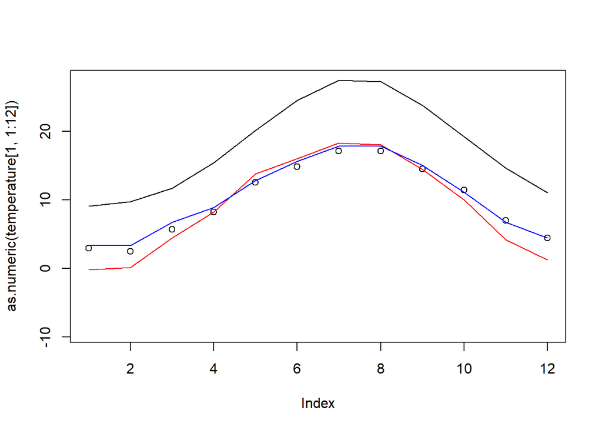

```r
plot(as.numeric(temperature[1,1:12]), ylim= range(temperature[,1:12]))
lines(as.numeric(temperature[2,1:12]))
lines(as.numeric(temperature[3,1:12]), col="red")
lines(as.numeric(temperature[4,1:12]), col="blue")
```

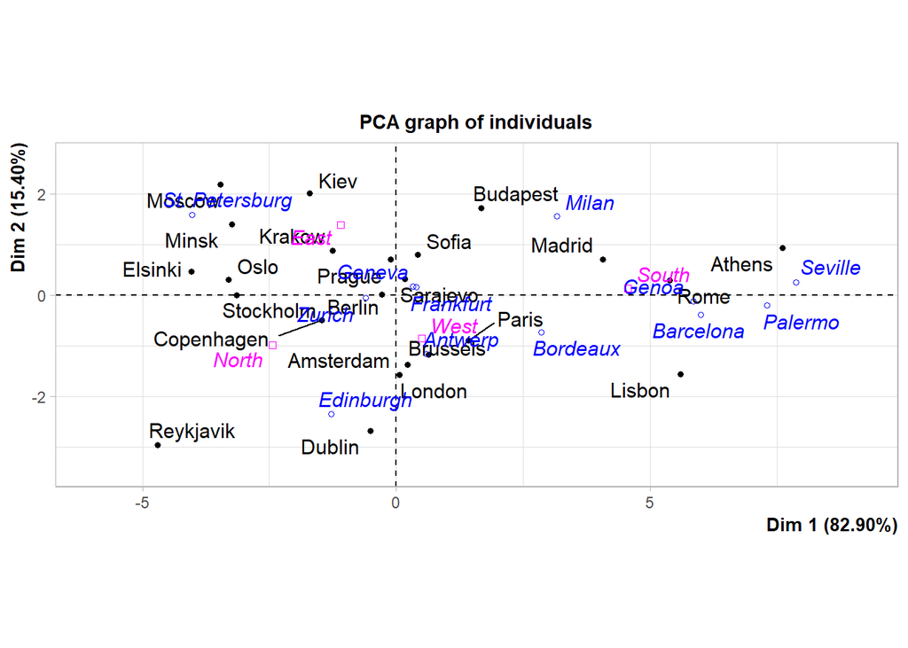

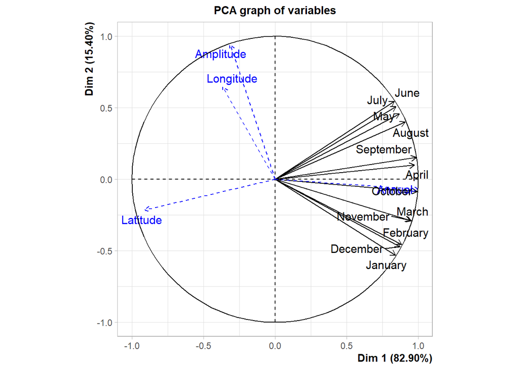

```r
res <- PCA(temperature,ind.sup=24:35,quanti.sup=13:16,quali.sup=17)
```

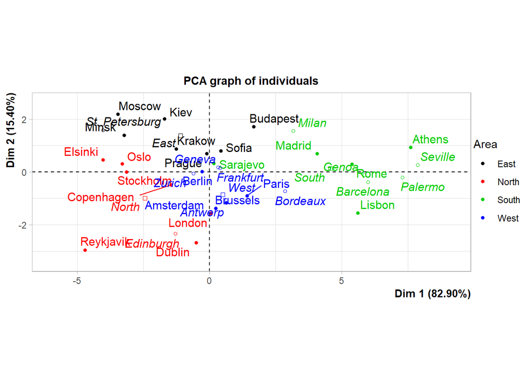

```r
plot.PCA(res,choix="ind",habillage=17)
```

L’axe 1 semble représenter l’axe nord/sud, tandis que l’axe 2 représente plutôt un axe est/ouest.

```r
dimdesc(res)
```

```
## $Dim.1
## $quanti
##           correlation      p.value
## Annual      0.9975483 9.575809e-26
## October     0.9916246 3.734359e-20
## September   0.9856254 1.056964e-17
## April       0.9738876 5.295583e-15
## November    0.9523567 2.659701e-12
## March       0.9450521 1.151422e-11
## August      0.9092443 1.904695e-09
## February    0.8842848 2.180620e-08
## December    0.8731191 5.450923e-08
## May         0.8698517 7.013036e-08
## July        0.8441626 4.129012e-07
## January     0.8424506 4.594275e-07
## June        0.8333141 7.957991e-07
## Latitude   -0.9099106 1.768178e-09
##
## $quali
##             R2      p.value
## Area 0.6787608 6.282082e-05
##
## $category
##             Estimate      p.value
## Area=South  4.182744 2.359137e-05
## Area=North -2.822709 1.241529e-02
##
## attr(,"class")
## [1] "condes" "list"
##
## $Dim.2
## $quanti
##           correlation      p.value
## Amplitude   0.9444140 1.296159e-11
## Longitude   0.6449726 8.912273e-04
## June        0.5453220 7.119942e-03
## July        0.5086619 1.319151e-02
## May         0.4578116 2.804268e-02
## February   -0.4558325 2.881655e-02
## December   -0.4728656 2.268397e-02
```

[output cut: 95 more lines]

```
## Kiev             30.3  Area=East
## Krakow           19.6  Area=East
## Lisbon            9.1 Area=South
## London            0.0 Area=North
## Madrid            3.4 Area=South
## Minsk            27.3  Area=East
## Moscow           37.6  Area=East
## Oslo             10.5 Area=North
## Paris             2.2  Area=West
## Prague           14.2  Area=East
## Reykjavik        21.6 Area=North
## Rome             12.3 Area=South
## Sarajevo         18.3 Area=South
## Sofia            23.2  Area=East
## Stockholm        18.0 Area=North
```

Les variables les plus corrélées à la composante 1 sont les températures annuelles, de septembre et d’octobre. Les variables les plus corrélées à la composante 2 sont l’amplitude des températures, la longitude et le mois de juin.

```r
res$eig
```

```
##           eigenvalue percentage of variance cumulative percentage of variance
## comp 1  9.9477504204           82.897920170                          82.89792
## comp 2  1.8476485015           15.397070846                          98.29499
## comp 3  0.1262558038            1.052131698                          99.34712
## comp 4  0.0382934463            0.319112052                          99.66623
## comp 5  0.0167094089            0.139245074                          99.80548
## comp 6  0.0128330357            0.106941964                          99.91242
## comp 7  0.0058302931            0.048585776                          99.96101
## comp 8  0.0020318929            0.016932441                          99.97794
## comp 9  0.0010234516            0.008528764                          99.98647
## comp 10 0.0009527707            0.007939756                          99.99441
## comp 11 0.0005367834            0.004473195                          99.99888
## comp 12 0.0001341917            0.001118264                         100.00000
```

Les deux premières composantes expliquent plus de 98% de la variance des données (resp. 83, 15). On peut donc ignorer les axes suivants.

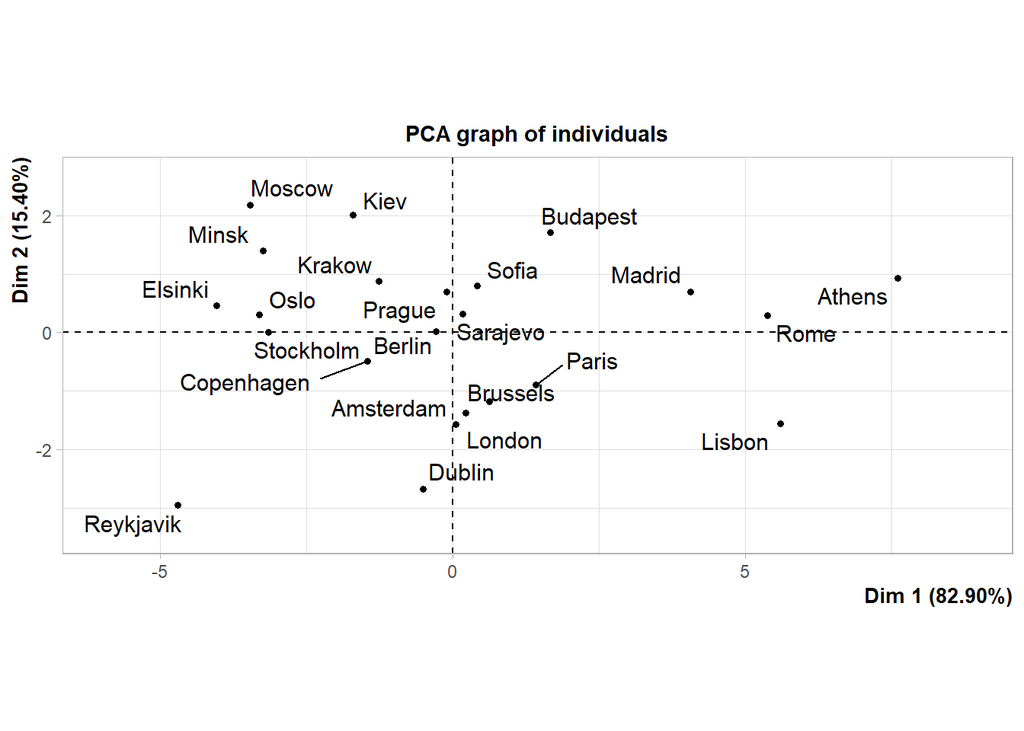

```r
plot.PCA(res, choix = c("ind"),
         invisible=c("ind.sup", "quali", "quanti.sup"))
```

Deux capitales représentatives de l’axe 1, resp. valeur minimale et maximale : Reykjavik et Athènes. Deux capitales représentatives de l’axe 2, resp. valeur minimale et maximale : Reykjavik et Moscou.

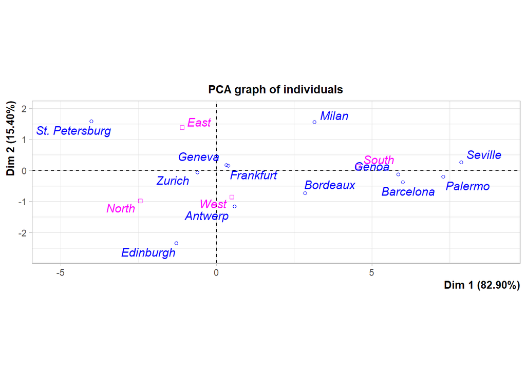

```r
plot.PCA(res, choix = c("ind"), invisible = c("ind"))
```

```r
res$ind.sup
```

```
## $coord
##                      Dim.1       Dim.2      Dim.3       Dim.4       Dim.5
## Antwerp          0.5892648 -1.16201065 -0.1268013 -0.15603707 -0.11613304
## Barcelona        5.9892460 -0.38329986  0.2505959  0.02163510 -0.01454736
## Bordeaux         2.8501570 -0.73131707 -0.2667125  0.18408602  0.11160661
## Edinburgh       -1.2889857 -2.34463780 -0.1810518  0.12244903  0.13465543
## Frankfurt        0.3890032  0.15364874 -0.4425226  0.16392128  0.21806343
## Geneva           0.3248580  0.17052566 -0.2552736  0.26348373  0.11926130
## Genoa            5.8482798 -0.12707972  0.3435118 -0.07839203 -0.22166243
## Milan            3.1561321  1.55567808 -0.2462565  0.36059254  0.03288711
## Palermo          7.2922522 -0.20543700 -0.5933018 -0.56911196  0.84223935
## Seville          7.8644835  0.25777733  0.2165506  0.10684270 -0.03926325
## St. Petersburg  -4.0229276  1.58587572  0.8134942  0.01896794 -0.32255205
## Zurich          -0.6082877 -0.05761394 -0.3660439  0.23729991  0.03837778
##
## $cos2
##                     Dim.1        Dim.2        Dim.3        Dim.4        Dim.5
## Antwerp         0.1954400 0.7599985442 0.0090498201 1.370402e-02 7.591090e-03
## Barcelona       0.9938250 0.0040704547 0.0017398563 1.296831e-05 5.863191e-06
## Bordeaux        0.9233629 0.0607919740 0.0080857757 3.851913e-03 1.415842e-03
## Edinburgh       0.2296285 0.7597680759 0.0045303838 2.072241e-03 2.505978e-03
## Frankfurt       0.3296074 0.0514219671 0.4265416849 5.852768e-02 1.035753e-01
## Geneva          0.3639175 0.1002755755 0.2247125471 2.393995e-01 4.904726e-02
## Genoa           0.9933376 0.0004690218 0.0034270781 1.784779e-04 1.427003e-03
## Milan           0.7906782 0.1921006780 0.0048135431 1.032103e-02 8.585011e-05
## Palermo         0.9689404 0.0007690083 0.0064139430 5.901591e-03 1.292542e-02
## Seville         0.9975864 0.0010717650 0.0007563603 1.841195e-04 2.486466e-05
## St. Petersburg  0.8295199 0.1289082379 0.0339196473 1.844093e-05 5.332637e-03
## Zurich          0.6401597 0.0057428226 0.2318123420 9.742387e-02 2.548179e-03
##
## $dist
##        Antwerp       Barcelona        Bordeaux       Edinburgh       Frankfurt
##       1.3329189       6.0078239       2.9660781       2.6898945       0.6775708
##         Geneva           Genoa           Milan         Palermo         Seville
##       0.5385080       5.8678595       3.5494028       7.4082076       7.8739915
## St. Petersburg          Zurich
##       4.4170144       0.7602648
```

Deux villes n’étant pas des capitales représentatives de l’axe 1 : Saint-Pétersbourg et Séville. Deux villes n’étant pas des capitales représentatives de l’axe 2 : Saint-Pétersbourg et Édimbourg.

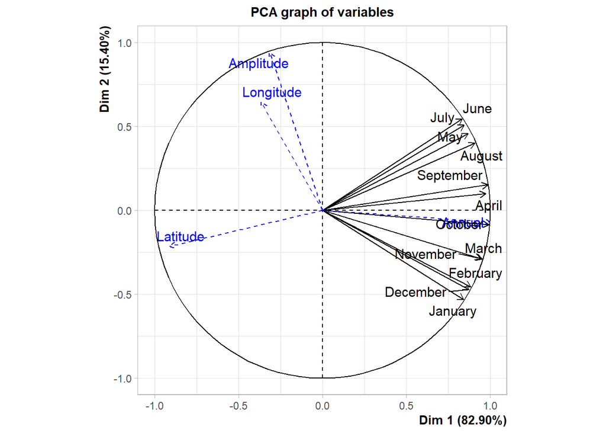

```r
plot.PCA(res, choix = "var")
```

```r
res$var
```

```
## $coord
##               Dim.1       Dim.2         Dim.3         Dim.4        Dim.5
## January   0.8424506 -0.53135762  6.776712e-02  1.168876e-02  0.031619528
## February  0.8842848 -0.45583250 -3.466272e-03  8.371472e-02  0.043624508
## March     0.9450521 -0.28731281 -1.207952e-01  7.781832e-02 -0.043317269
## April     0.9738876  0.09956500 -1.982562e-01  2.486767e-02  0.016577380
## May       0.8698517  0.45781159 -1.560861e-01 -7.682512e-02  0.031288335
## June      0.8333141  0.54532195  4.954763e-02  9.575733e-05  0.058509054
## July      0.8441626  0.50866195  1.536892e-01  4.360395e-02  0.003553866
## August    0.9092443  0.40192442  8.750079e-02  4.439218e-02 -0.036429060
## September 0.9856254  0.15253617  2.262618e-02  5.193042e-03 -0.043630460
## October   0.9916246 -0.08476471 -6.661858e-05 -7.173534e-02 -0.059633790
## November  0.9523567 -0.28941418  4.422075e-02 -6.973744e-02 -0.002706470
## December  0.8731191 -0.47286559  8.480816e-02 -6.829538e-02  0.021123796
##
## $cor
##               Dim.1       Dim.2         Dim.3         Dim.4        Dim.5
## January   0.8424506 -0.53135762  6.776712e-02  1.168876e-02  0.031619528
## February  0.8842848 -0.45583250 -3.466272e-03  8.371472e-02  0.043624508
## March     0.9450521 -0.28731281 -1.207952e-01  7.781832e-02 -0.043317269
## April     0.9738876  0.09956500 -1.982562e-01  2.486767e-02  0.016577380
## May       0.8698517  0.45781159 -1.560861e-01 -7.682512e-02  0.031288335
## June      0.8333141  0.54532195  4.954763e-02  9.575733e-05  0.058509054
## July      0.8441626  0.50866195  1.536892e-01  4.360395e-02  0.003553866
## August    0.9092443  0.40192442  8.750079e-02  4.439218e-02 -0.036429060
## September 0.9856254  0.15253617  2.262618e-02  5.193042e-03 -0.043630460
## October   0.9916246 -0.08476471 -6.661858e-05 -7.173534e-02 -0.059633790
## November  0.9523567 -0.28941418  4.422075e-02 -6.973744e-02 -0.002706470
## December  0.8731191 -0.47286559  8.480816e-02 -6.829538e-02  0.021123796
##
## $cos2
##               Dim.1       Dim.2        Dim.3        Dim.4        Dim.5
## January   0.7097230 0.282340915 4.592383e-03 1.366271e-04 9.997946e-04
## February  0.7819596 0.207783268 1.201504e-05 7.008155e-03 1.903098e-03
## March     0.8931235 0.082548649 1.459148e-02 6.055690e-03 1.876386e-03
## April     0.9484570 0.009913188 3.930551e-02 6.184011e-04 2.748095e-04
## May       0.7566419 0.209591455 2.436286e-02 5.902099e-03 9.789599e-04
## June      0.6944124 0.297376030 2.454967e-03 9.169466e-09 3.423309e-03
## July      0.7126106 0.258736979 2.362036e-02 1.901305e-03 1.262996e-05
## August    0.8267252 0.161543240 7.656389e-03 1.970666e-03 1.327076e-03
## September 0.9714575 0.023267284 5.119442e-04 2.696769e-05 1.903617e-03
## October   0.9833194 0.007185057 4.438035e-09 5.145958e-03 3.556189e-03
## November  0.9069833 0.083760565 1.955475e-03 4.863310e-03 7.324982e-06
## December  0.7623370 0.223601871 7.192425e-03 4.664259e-03 4.462148e-04
##
## $contrib
##              Dim.1      Dim.2        Dim.3        Dim.4       Dim.5
## January   7.134508 15.2810946 3.637364e+00 3.567898e-01  5.98342273
## February  7.860668 11.2458224 9.516430e-03 1.830119e+01 11.38937776
## March     8.978146  4.4677680 1.155707e+01 1.581391e+01 11.22951624
## April     9.534387  0.5365300 3.113164e+01 1.614901e+00  1.64463940
## May       7.606161 11.3436865 1.929643e+01 1.541282e+01  5.85873440
## June      6.980597 16.0948378 1.944439e+00 2.394526e-05 20.48731569
## July      7.163535 14.0035823 1.870833e+01 4.965091e+00  0.07558593
## August    8.310674  8.7431803 6.064187e+00 5.146222e+00  7.94209075
## September 9.765600  1.2592917 4.054817e-01 7.042377e-02 11.39248596
## October   9.884842  0.3888757 3.515114e-06 1.343822e+01 21.28255345
## November  9.117472  4.5333604 1.548820e+00 1.270011e+01  0.04383747
## December  7.663411 12.1019702 5.696708e+00 1.218030e+01  2.67044021
```

Les mois qui contribuent le plus à l’inertie de l’axe 1 : octobre, septembre, avril. Les mois qui contribuent le plus à l’inertie de l’axe 2 : juin, janvier, juillet.

```r
res$quanti.sup
```

```
## $coord
##                Dim.1       Dim.2        Dim.3         Dim.4        Dim.5
## Annual     0.9975483 -0.06845254  0.004566805 -3.575494e-06  0.002369337
## Amplitude -0.3140756  0.94441398  0.039188355  5.742427e-03 -0.034458137
## Latitude  -0.9099106 -0.21543731  0.181984525 -5.929010e-02  0.127730013
## Longitude -0.3644584  0.64497259 -0.036433872 -2.473234e-01  0.183461039
##
## $cor
##                Dim.1       Dim.2        Dim.3         Dim.4        Dim.5
## Annual     0.9975483 -0.06845254  0.004566805 -3.575494e-06  0.002369337
## Amplitude -0.3140756  0.94441398  0.039188355  5.742427e-03 -0.034458137
## Latitude  -0.9099106 -0.21543731  0.181984525 -5.929010e-02  0.127730013
## Longitude -0.3644584  0.64497259 -0.036433872 -2.473234e-01  0.183461039
##
## $cos2
##                Dim.1      Dim.2        Dim.3        Dim.4        Dim.5
## Annual    0.99510271 0.00468575 2.085571e-05 1.278416e-11 5.613758e-06
## Amplitude 0.09864347 0.89191777 1.535727e-03 3.297546e-05 1.187363e-03
## Latitude  0.82793735 0.04641323 3.311837e-02 3.515315e-03 1.631496e-02
## Longitude 0.13282993 0.41598964 1.327427e-03 6.116887e-02 3.365795e-02
```

Les variables “annual” et “latitude” peuvent être rattachées à l’axe 1. Les variables “amplitude” et “longitude” peuvent être rattachées à l’axe 2.

```r
res$quali.sup
```

```
## $coord
##            Dim.1      Dim.2      Dim.3         Dim.4        Dim.5
## East  -1.0992214  1.3802437 -0.2572321 -0.0006256493  0.034207046
## North -2.4435569 -0.9884068  0.2686340  0.0149430227  0.064999941
## South  4.5618962  0.1373766  0.1155118  0.0600323112 -0.004894398
## West   0.4974918 -0.8574352 -0.1643430 -0.1000957922 -0.167494229
##
## $cos2
##           Dim.1        Dim.2        Dim.3        Dim.4        Dim.5
## East  0.3797241 0.5987000663 0.0207944802 1.230155e-07 3.677299e-04
## North 0.8499535 0.1390662460 0.0102724038 3.178536e-05 6.014177e-04
## South 0.9981689 0.0009051878 0.0006399795 1.728556e-04 1.148978e-06
## West  0.2323311 0.6901414045 0.0253535084 9.405180e-03 2.633511e-02
##
## $v.test
##            Dim.1      Dim.2      Dim.3        Dim.4       Dim.5
## East  -1.0812425  3.1502604 -2.2459487 -0.009919028  0.82098532
## North -2.4035900 -2.2559342  2.3455009  0.236906293  1.56002942
## South  3.5755516  0.2498407  0.8036386  0.758373112 -0.09360064
## West   0.3394596 -1.3575510 -0.9953829 -1.100824611 -2.78858470
##
## $dist
##     East    North    South     West
## 1.783820 2.650482 4.566079 1.032125
##
## $eta2
##          Dim.1     Dim.2     Dim.3      Dim.4    Dim.5
## Area 0.6787608 0.5461533 0.3936374 0.06773989 0.390571
```

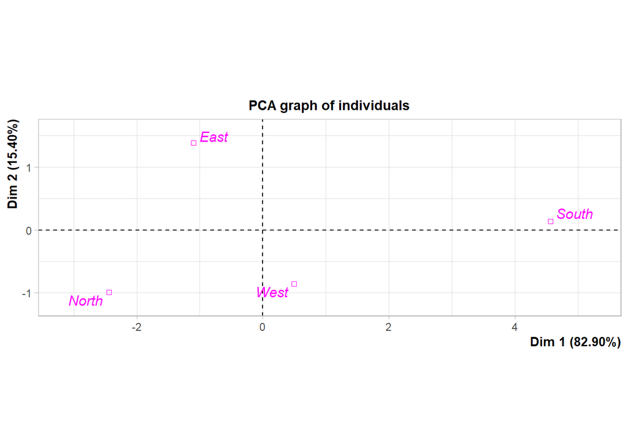

```r
plot.PCA(res, choix = "ind", invisible = c("ind", "ind.sup"))
```

La catégorie “East” est plus corrélée à la composante 2 qu’à la composante 1. Cette corrélation est positive. En se basant sur les composantes de l’ACP, on peut prédire que janvier sera négativement corrélé avec amplitude.  
Typologie sommaire des températures en Europe :  
- Au nord, il fait froid ; au sud, il fait chaud.  
- Certaines villes subissent une plus grande amplitude de températures, càd des températures très froides en hiver et très chaudes en été. Ces villes ont tendance à se situer à l’est, tandis que les villes occidentales ont des amplitudes de températures moindres.  
### Jeux olympiques

```r
data(JO)
apply(JO, 1, sum)
```

```
##       10000m         100m        110mH        1500m         200m         20km
##           15           15           15           15           15           15
## 3000mSteeple         400m        400mH       4x100m       4x400m        5000m
##           15           15           15           15           15           15
##         50km         800m    Decathlon       Disque      Hauteur      Javelot
##           15           15           15           15           15           15
##     Longueur     Marathon      Marteau       Perche        Poids  Triple saut
##           15           15           15           15           15           15
```

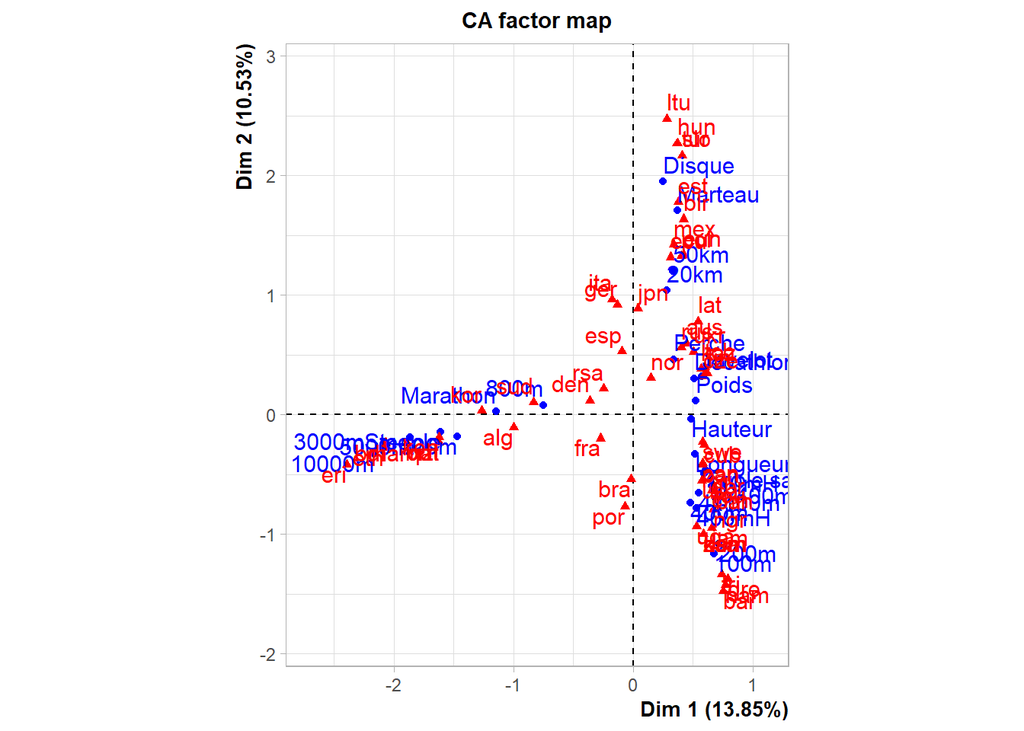

```r
resJO <- CA(JO)
```

```r
summary(resJO)
```

```
##
## Call:
## CA(X = JO)
##
## The chi square of independence between the two variables is equal to 2122.231 (p-value =  2.320981e-41 ).
##
## Eigenvalues
##                        Dim.1   Dim.2   Dim.3   Dim.4   Dim.5   Dim.6   Dim.7
## Variance               0.817   0.621   0.544   0.481   0.396   0.364   0.327
## % of var.             13.854  10.529   9.232   8.162   6.721   6.174   5.554
## Cumulative % of var.  13.854  24.383  33.615  41.778  48.499  54.673  60.226
##                        Dim.8   Dim.9  Dim.10  Dim.11  Dim.12  Dim.13  Dim.14
## Variance               0.315   0.269   0.245   0.230   0.183   0.164   0.145
## % of var.              5.351   4.560   4.156   3.910   3.107   2.783   2.457
## Cumulative % of var.  65.577  70.137  74.293  78.203  81.310  84.093  86.550
##                       Dim.15  Dim.16  Dim.17  Dim.18  Dim.19  Dim.20  Dim.21
## Variance               0.131   0.121   0.103   0.093   0.085   0.079   0.075
## % of var.              2.218   2.056   1.756   1.584   1.437   1.347   1.266
## Cumulative % of var.  88.767  90.824  92.579  94.164  95.601  96.948  98.214
##                       Dim.22  Dim.23
## Variance               0.062   0.043
## % of var.              1.052   0.734
## Cumulative % of var.  99.266 100.000
##
## Rows (the 10 first)
##                Iner*1000     Dim.1     ctr    cos2     Dim.2     ctr    cos2
## 10000m       |   366.587 |  -2.162  23.850   0.531 |  -0.330   0.730   0.012 |
## 100m         |   262.733 |   0.678   2.347   0.073 |  -1.164   9.093   0.215 |
## 110mH        |   157.044 |   0.593   1.795   0.093 |  -0.498   1.665   0.066 |
## 1500m        |   338.175 |  -1.469  11.016   0.266 |  -0.185   0.229   0.004 |
## 200m         |   199.995 |   0.716   2.612   0.107 |  -1.084   7.889   0.245 |
## 20km         |   330.785 |   0.284   0.411   0.010 |   1.037   7.213   0.135 |
## 3000mSteeple |   271.032 |  -1.610  13.230   0.399 |  -0.147   0.146   0.003 |
## 400m         |   137.131 |   0.480   1.177   0.070 |  -0.736   3.639   0.165 |
## 400mH        |   265.578 |   0.532   1.444   0.044 |  -0.785   4.137   0.097 |
## 4x100m       |   202.241 |   0.550   1.542   0.062 |  -0.654   2.870   0.088 |
##                Dim.3     ctr    cos2
## 10000m        -0.172   0.227   0.003 |
## 100m          -0.407   1.267   0.026 |
## 110mH         -0.395   1.196   0.041 |
```

[output cut: 16 more lines]

```
## bra          |   102.778 |  -0.016   0.000   0.000 |  -0.543   0.395   0.024 |
## brn          |    63.889 |  -1.626   0.899   0.115 |  -0.234   0.025   0.002 |
## can          |    55.556 |   0.582   0.461   0.068 |  -0.406   0.295   0.033 |
## chn          |    63.889 |   0.656   0.147   0.019 |  -0.632   0.179   0.017 |
##                Dim.3     ctr    cos2
## alg            0.342   0.239   0.023 |
## aus            0.959   2.815   0.212 |
## bah            0.442   0.299   0.016 |
## bar           -0.552   0.155   0.013 |
## bdi           -0.120   0.007   0.001 |
## blr           -1.376   5.796   0.334 |
## bra           -0.516   0.408   0.022 |
## brn            0.506   0.131   0.011 |
## can            0.094   0.018   0.002 |
## chn           -0.536   0.147   0.012 |
```

```r
## profils lignes
rowprof <- JO / apply(JO, 1, sum)
apply(rowprof,1,sum)
```

```
##       10000m         100m        110mH        1500m         200m         20km
##            1            1            1            1            1            1
## 3000mSteeple         400m        400mH       4x100m       4x400m        5000m
##            1            1            1            1            1            1
##         50km         800m    Decathlon       Disque      Hauteur      Javelot
##            1            1            1            1            1            1
##     Longueur     Marathon      Marteau       Perche        Poids  Triple saut
##            1            1            1            1            1            1
```

```r
## profils colonnes
colprof <- t(t(JO) / apply(JO, 2, sum)) #t() : transposee
apply(colprof,2,sum)
```

```
## alg aus bah bar bdi blr bra brn can chn cub cze den dom ecu eri esp est eth eun
##   1   1   1   1   1   1   1   1   1   1   1   1   1   1   1   1   1   1   1   1
## fin fra gbr ger gre hun ita jam jpn kaz ken kor ksa lat ltu mar mex nam ngr nor
##   1   1   1   1   1   1   1   1   1   1   1   1   1   1   1   1   1   1   1   1
## nzl pan pol por qat rou rsa rus slo sud swe tch tri tur uga ukr usa zam
##   1   1   1   1   1   1   1   1   1   1   1   1   1   1   1   1   1   1
```

```r
round(resJO$eig,1)
```

```
##        eigenvalue percentage of variance cumulative percentage of variance
## dim 1         0.8                   13.9                              13.9
## dim 2         0.6                   10.5                              24.4
## dim 3         0.5                    9.2                              33.6
## dim 4         0.5                    8.2                              41.8
## dim 5         0.4                    6.7                              48.5
## dim 6         0.4                    6.2                              54.7
## dim 7         0.3                    5.6                              60.2
## dim 8         0.3                    5.4                              65.6
## dim 9         0.3                    4.6                              70.1
## dim 10        0.2                    4.2                              74.3
## dim 11        0.2                    3.9                              78.2
## dim 12        0.2                    3.1                              81.3
## dim 13        0.2                    2.8                              84.1
## dim 14        0.1                    2.5                              86.5
## dim 15        0.1                    2.2                              88.8
## dim 16        0.1                    2.1                              90.8
## dim 17        0.1                    1.8                              92.6
## dim 18        0.1                    1.6                              94.2
## dim 19        0.1                    1.4                              95.6
## dim 20        0.1                    1.3                              96.9
## dim 21        0.1                    1.3                              98.2
## dim 22        0.1                    1.1                              99.3
## dim 23        0.0                    0.7                             100.0
```

Il faudrait garder 6 dimensions pour expliquer plus de 50% de la variance (54.7%)

```r
chisq.test(JO)
```

```
##
##  Pearson's Chi-squared test
##
## data:  JO
## X-squared = 2122.2, df = 1311, p-value < 2.2e-16
```

```r
resJO$row$coord
```

```
##                   Dim 1       Dim 2       Dim 3        Dim 4       Dim 5
## 10000m       -2.1621177 -0.32982549 -0.17204577  0.081633874  0.55486198
## 100m          0.6783149 -1.16388948 -0.40688358 -0.332956787 -0.12331848
## 110mH         0.5931714 -0.49798366 -0.39525262 -0.053903841 -0.25834929
## 1500m        -1.4694381 -0.18472477  0.37332390 -0.196623725 -0.69096273
## 200m          0.7155408 -1.08408289 -0.46829289 -0.211556635  0.01916550
## 20km          0.2838737  1.03661465  1.47590265 -1.515023258 -0.82420805
## 3000mSteeple -1.6103379 -0.14740343  0.12688933 -0.090885749 -0.15233215
## 400m          0.4802545 -0.73624878 -0.31218478 -0.056116610  0.04682458
## 400mH         0.5320823 -0.78505635 -0.40642826 -0.068597697 -0.03721406
## 4x100m        0.5497460 -0.65390541 -0.39651100 -0.263291744  0.19379449
## 4x400m        0.6595150 -0.59592831  0.06796214 -0.129165251 -0.09757978
## 5000m        -1.8671256 -0.18726132 -0.08846354  0.135515200  0.05999955
## 50km          0.3318944  1.20030297  1.17299464 -0.747038891 -0.26773101
## 800m         -0.7509634  0.07984624  0.15379693  0.539658031 -0.23351758
## Decathlon     0.5120847  0.30133685 -0.08254275  1.032463527 -0.15580067
## Disque        0.2517965  1.94790027 -1.79326276  1.115289280 -1.49007590
## Hauteur       0.4839793 -0.03760759  0.57031734  0.266455666 -0.20350760
## Javelot       0.5716717  0.32186729  1.75954398  2.120987135  1.00826615
## Longueur      0.5191249 -0.33019534 -0.21180289 -0.269505397 -0.16562749
## Marathon     -1.1433486  0.02533805 -0.34884371 -0.134101840  0.40994637
## Marteau       0.3712894  1.70731438 -1.08423488 -0.834993960  1.95647718
## Perche        0.3396610  0.46204966  0.26312975 -0.605913722  0.16348719
## Poids         0.5229643  0.11540302 -0.25192644  0.005747727  0.57077733
## Triple saut   0.6063664 -0.46386058  0.45481520  0.211924666 -0.28337554
```

```r
n <- sum(JO)
rowW <- apply(JO,1,sum)/n
rowW
```

```
##       10000m         100m        110mH        1500m         200m         20km
##   0.04166667   0.04166667   0.04166667   0.04166667   0.04166667   0.04166667
## 3000mSteeple         400m        400mH       4x100m       4x400m        5000m
##   0.04166667   0.04166667   0.04166667   0.04166667   0.04166667   0.04166667
##         50km         800m    Decathlon       Disque      Hauteur      Javelot
##   0.04166667   0.04166667   0.04166667   0.04166667   0.04166667   0.04166667
##     Longueur     Marathon      Marteau       Perche        Poids  Triple saut
##   0.04166667   0.04166667   0.04166667   0.04166667   0.04166667   0.04166667
```

```r
colW <- apply(JO,2,sum)/n
colW
```

```
##         alg         aus         bah         bar         bdi         blr
## 0.011111111 0.016666667 0.008333333 0.002777778 0.002777778 0.016666667
##         bra         brn         can         chn         cub         cze
## 0.008333333 0.002777778 0.011111111 0.002777778 0.038888889 0.016666667
##         den         dom         ecu         eri         esp         est
## 0.008333333 0.002777778 0.005555556 0.002777778 0.022222222 0.008333333
##         eth         eun         fin         fra         gbr         ger
## 0.041666667 0.019444444 0.011111111 0.008333333 0.041666667 0.027777778
##         gre         hun         ita         jam         jpn         kaz
## 0.002777778 0.008333333 0.019444444 0.025000000 0.011111111 0.002777778
##         ken         kor         ksa         lat         ltu         mar
## 0.097222222 0.005555556 0.002777778 0.008333333 0.011111111 0.027777778
##         mex         nam         ngr         nor         nzl         pan
## 0.011111111 0.011111111 0.011111111 0.008333333 0.002777778 0.002777778
##         pol         por         qat         rou         rsa         rus
## 0.022222222 0.008333333 0.002777778 0.002777778 0.016666667 0.052777778
##         slo         sud         swe         tch         tri         tur
## 0.002777778 0.002777778 0.008333333 0.005555556 0.016666667 0.002777778
##         uga         ukr         usa         zam
## 0.002777778 0.013888889 0.227777778 0.002777778
```

```r
sum(resJO$row$coord[,"Dim 1"]*rowW)
```

```
## [1] -3.243933e-16
```

```r
sum(resJO$row$coord[,"Dim 2"]*rowW)
```

```
## [1] 1.634977e-16
```

Le barycentre des projections des profils lignes sur les deux premiers axes est le vecteur nul.

```r
var(resJO$row$coord[,"Dim 1"]) == resJO$eig["dim 1", "eigenvalue"]
```

```
## [1] FALSE
```

```r
cor(resJO$row$coord[,"Dim 1"],resJO$row$coord[,"Dim 2"])
```

```
## [1] 1.701065e-16
```

```r
resJO$row$contrib[,1] == resJO$row$coord[,"Dim 1"]*rowW*resJO$eig["dim 1", "eigenvalue"]
```

```
##       10000m         100m        110mH        1500m         200m         20km
##        FALSE        FALSE        FALSE        FALSE        FALSE        FALSE
## 3000mSteeple         400m        400mH       4x100m       4x400m        5000m
##        FALSE        FALSE        FALSE        FALSE        FALSE        FALSE
##         50km         800m    Decathlon       Disque      Hauteur      Javelot
##        FALSE        FALSE        FALSE        FALSE        FALSE        FALSE
##     Longueur     Marathon      Marteau       Perche        Poids  Triple saut
##        FALSE        FALSE        FALSE        FALSE        FALSE        FALSE
```

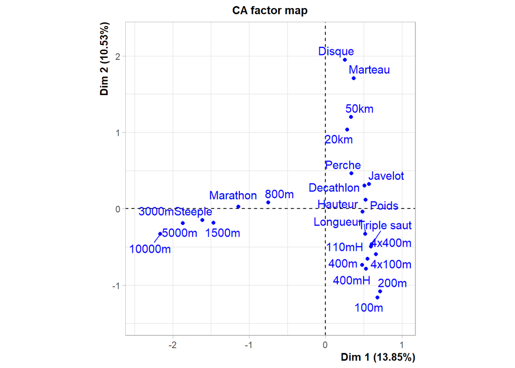

```r
plot.CA(resJO, invisible="col")
```

L’axe 1 semble représenter les épreuves d’endurance (valeurs négatives -> épreuves longues, valeurs positives -> épreuves rapides), à l’exception des épreuves 20 et 50 km L’axe 2 semble représenter la “partie du corps” impliquée dans les épreuves (valeurs positives -> bras, valeurs négatives -> jambes), à l’exception à nouveau des épreuves 20 et 50 km

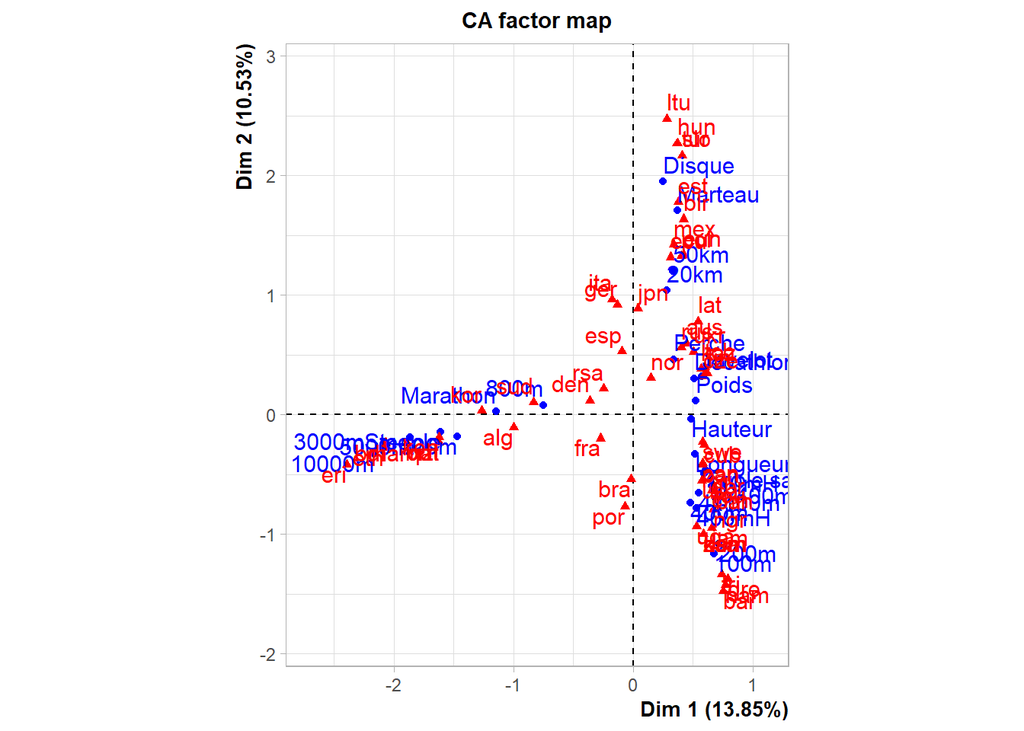

```r
plot.CA(resJO)
```

```r
contr <- resJO$col$contrib[,1]
contr[rev(order(contr))]
```

```
##          ken          eth          mar          usa          gbr          eri
## 3.138746e+01 2.207207e+01 1.216012e+01 9.149014e+00 2.138849e+00 1.946855e+00
##          cub          bdi          alg          jam          tri          kor
## 1.682821e+00 1.451851e+00 1.351997e+00 1.312694e+00 1.119340e+00 1.088836e+00
##          rus          qat          nzl          brn          nam          cze
## 1.048031e+00 8.992441e-01 8.992441e-01 8.992441e-01 8.091157e-01 6.946731e-01
##          ngr          fin          bah          can          pol          ukr
## 6.089969e-01 5.214675e-01 4.866093e-01 4.613844e-01 4.407045e-01 4.314704e-01
##          eun          aus          blr          swe          lat          tch
## 4.171853e-01 4.058035e-01 3.612089e-01 3.440666e-01 3.021189e-01 2.445729e-01
##          sud          gre          bar          mex          rou          chn
## 2.348619e-01 2.132278e-01 1.916186e-01 1.579099e-01 1.531247e-01 1.465330e-01
##          est          hun          den          rsa          zam          ksa
## 1.432075e-01 1.372633e-01 1.330411e-01 1.250560e-01 1.179051e-01 1.179051e-01
##          dom          pan          kaz          ltu          uga          ita
## 1.179051e-01 1.122325e-01 1.092090e-01 1.056172e-01 9.605455e-02 7.773938e-02
##          fra          ecu          ger          tur          slo          esp
## 7.572965e-02 6.712051e-02 6.292828e-02 5.741165e-02 5.741165e-02 2.325471e-02
##          nor          por          jpn          bra
## 2.137310e-02 4.738649e-03 2.310727e-03 2.670075e-04
```

Les 5 pays contribuant le plus à l’inertie sur l’axe 1 sont : le Kenya, l’Éthiopie, le Maroc, les États-Unis, le Royaume-Uni

```r
resJO$col$coord["usa","Dim 1"]
```

```
## [1] 0.572746
```

Les États-Unis se situent du côté positif de l’axe endurance (valeurs positives -> faible endurance).  
### ACM

```r
data(banque)
dim(banque)
```

```
## [1] 810  21
```

```r
names(banque)
```

```
##  [1] "csp"      "duree"    "oppo"     "age"      "sexe"     "interdit"
##  [7] "cableue"  "assurvi"  "soldevu"  "eparlog"  "eparliv"  "credhab"
## [13] "credcon"  "versesp"  "retresp"  "remiche"  "preltre"  "prelfin"
## [19] "viredeb"  "virecre"  "porttit"
```

```r
head(banque)
```

```
##     csp duree oppo  age sexe interdit cableue assurvi soldevu eparlog eparliv
## 1 ouvri   d48  non ai75  hom      non     non     non      n1     nul     nul
## 2 cadsu   d24  non ai35  hom      non     non     non      n1     nul     nul
## 3 cadsu   d48  non ai75  hom      non     non     non      p1     nul     nul
## 4 inact   d24  non ai45  fem      oui     non     non      p2     nul     nul
## 5 retra  d812  non ai75  hom      non     non     non      p4     nul     nul
## 6 inact  dp12  non ai45  fem      non     non     non      p1     nul     nul
##   credhab credcon versesp retresp remiche preltre prelfin viredeb virecre
## 1     non     nul     non     fai     nul     nul     nul     nul     nul
## 2     non     nul     non     fai     nul     nul     nul     nul     nul
## 3     non     nul     non     fai     nul     nul     nul     nul     nul
## 4     non     nul     oui     fai     fai     nul     nul     nul     nul
## 5     non     nul     non     fai     nul     nul     nul     fai     nul
## 6     non     nul     non     fai     nul     nul     nul     nul     nul
##   porttit
## 1     nul
## 2     nul
## 3     nul
## 4     moy
## 5     for
## 6     nul
```

```r
# par(mfrow=c(5,1))
ids <- c(4,5,6,12,13)
# for(id in ids)
# {
#     barplot(banque[,id])
# }
idSup <- setdiff(1:21, ids )
tabdisj <- tab.disjonctif(banque[,ids])
colnames(tabdisj)
```

```
##      age1      age2      age3      age4      age5     sexe1     sexe2 interdit1
##    "ai25"    "ai35"    "ai45"    "ai55"    "ai75"     "hom"     "fem"     "non"
## interdit2  credhab1  credhab2  credcon1  credcon2  credcon3
##     "oui"     "non"     "oui"     "nul"     "fai"     "for"
```

```r
head(tabdisj)
```

```
##   ai25 ai35 ai45 ai55 ai75 hom fem non oui non oui nul fai for
## 1    0    0    0    0    1   1   0   1   0   1   0   1   0   0
## 2    0    1    0    0    0   1   0   1   0   1   0   1   0   0
## 3    0    0    0    0    1   1   0   1   0   1   0   1   0   0
## 4    0    0    1    0    0   0   1   0   1   1   0   1   0   0
## 5    0    0    0    0    1   1   0   1   0   1   0   1   0   0
## 6    0    0    1    0    0   0   1   1   0   1   0   1   0   0
```

La somme de chaque ligne est de 5 (le nombre de colonnes sélectionnées). La somme totale est donc de 810*5 = 4050.

```r
colSums(tabdisj)
```

```
## ai25 ai35 ai45 ai55 ai75  hom  fem  non  oui  non  oui  nul  fai  for
##   90  156  212  174  178  558  252  752   58  718   92  685   68   57
```

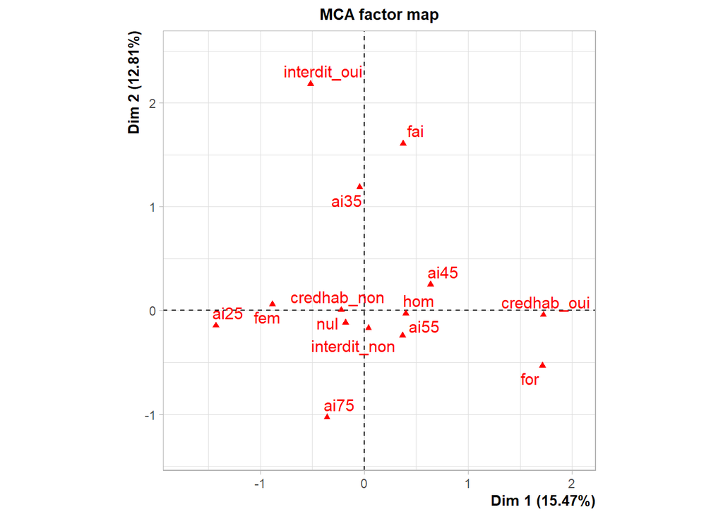

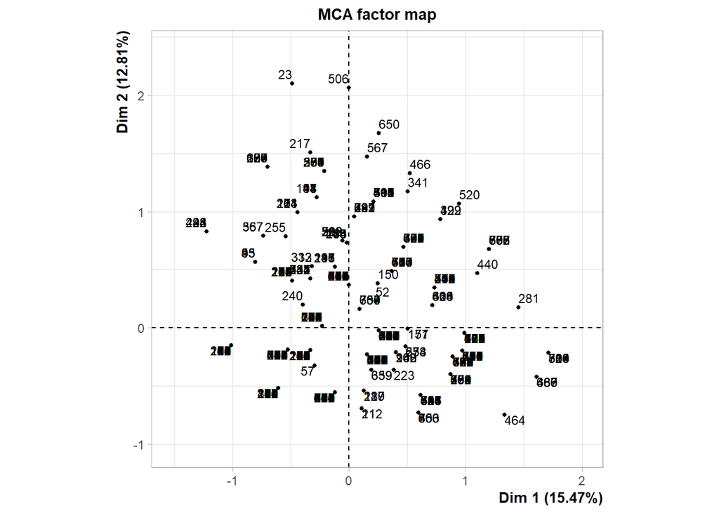

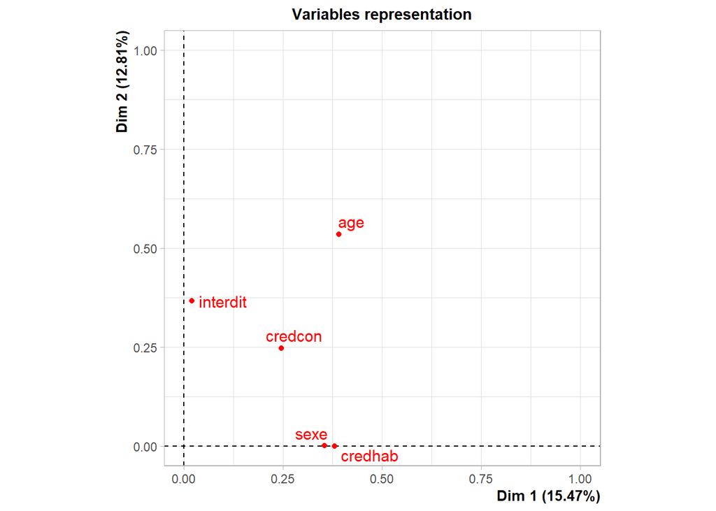

```r
resMCA <- MCA(banque[,ids])
```

Le premier plot représente les modalités des colonnes sur les axes de la MCA. Le deuxième représente les individus sur les axes de la MCA. Le troisième représente les colonnes sur les axes de la MCA.

```r
resMCA$eig
```

```
##       eigenvalue percentage of variance cumulative percentage of variance
## dim 1  0.2784897              15.471651                          15.47165
## dim 2  0.2305059              12.805884                          28.27753
## dim 3  0.2169931              12.055172                          40.33271
## dim 4  0.2031491              11.286062                          51.61877
## dim 5  0.1937988              10.766601                          62.38537
## dim 6  0.1816380              10.090999                          72.47637
## dim 7  0.1765235               9.806860                          82.28323
## dim 8  0.1627591               9.042173                          91.32540
## dim 9  0.1561428               8.674597                         100.00000
```

```r
chisq.test(tabdisj)
```

```
##
##  Pearson's Chi-squared test
##
## data:  tabdisj
## X-squared = 7290, df = 10517, p-value = 1
```

```r
ctrs <- resMCA$var$contrib[,1]
ctrs
```

```
##         ai25         ai35         ai45         ai55         ai75          hom
##   16.3089874    0.0265193    7.6307547    2.0962234    2.0223671    7.9131619
##          fem interdit_non interdit_oui  credhab_non  credhab_oui          nul
##   17.5220013    0.1058600    1.3725299    3.1032397   24.2187618    1.9642714
##          fai          for
##    0.8414283   14.8738939
```

Les trois modalités qui contribuent le plus à l’axe 1 sont la présence d’un crédit habitation, d’être dans la première tranche d’âge et d’être une femme.

```r
ctrs <- resMCA$var$contrib[,2]
ctrs
```

```
##         ai25         ai35         ai45         ai55         ai75          hom
##  0.203586386 23.573131838  1.412978850  1.079825633 20.198705801  0.044456400
##          fem interdit_non interdit_oui  credhab_non  credhab_oui          nul
##  0.098439171  2.281280057 29.577975915  0.002277597  0.017775158  0.976971363
##          fai          for
## 18.813695289  1.718900543
```

Les trois modalités qui contribuent le plus à l’axe 2 sont le fait d’être interdit bancaire, et le fait d’appartenir à la deuxième ou à la dernière tranche d’âge.

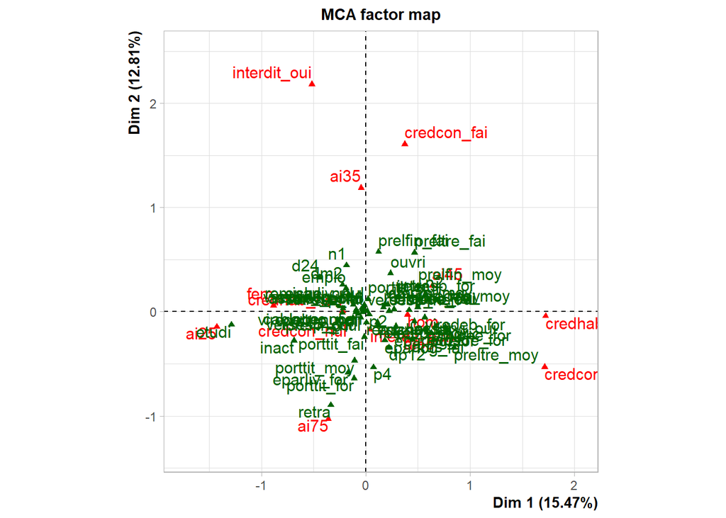

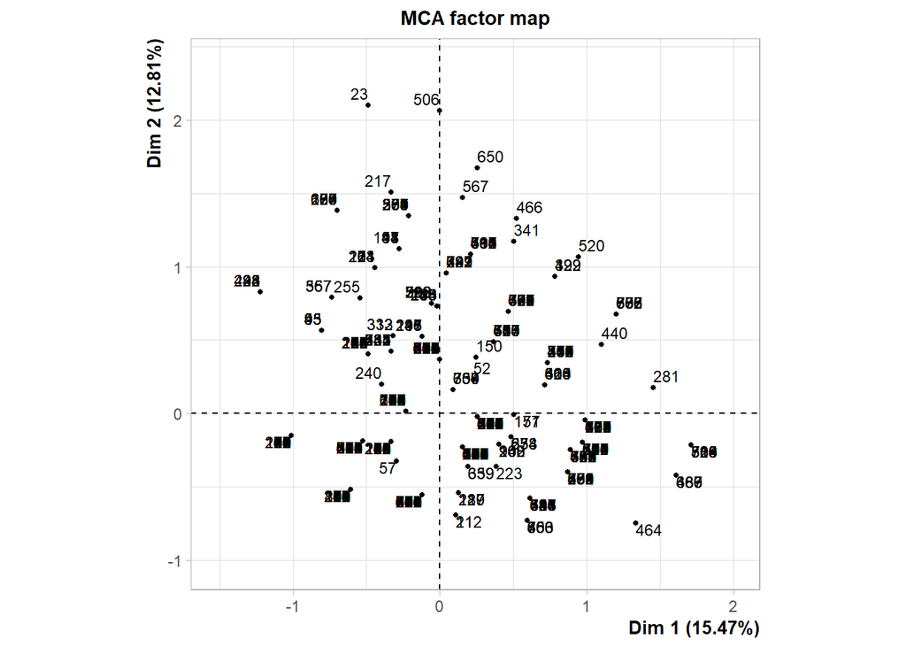

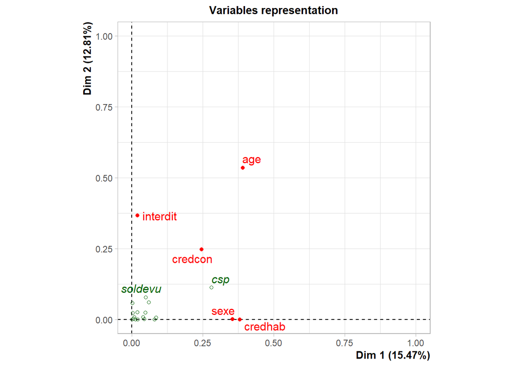

```r
resMCA <- MCA(banque, quali.sup = idSup)
```

```r
graphics.off()
plot.MCA(resMCA, choix = "ind", invisible = "ind", selectMod = "cos2 30",
         unselect = "gray50")
```

[output not shown]